# EDA Project Diamond Prices

Francia Moscoso

March 2, 2016

**Loading Libraries and ‘diamonds’ data set**

```r
library(ggplot2)
library(gridExtra)
library(dplyr)
library(lubridate)
```

To set up working directory: setwd(“~/SprintboardProject”)

Use function install.packages(“LibraryName”) to install data and time package

To silence the execution of the library function eg.library(dplyr), use statement: {r message=F, warning=F}

```r
data("diamonds")
str(diamonds)
```

```
Classes 'tbl_df', 'tbl' and 'data.frame':   53940 obs. of  10 variables:
 $ carat  : num  0.23 0.21 0.23 0.29 0.31 0.24 0.24 0.26 0.22 0.23 ...
 $ cut    : Ord.factor w/ 5 levels "Fair"<"Good"<..: 5 4 2 4 2 3 3 3 1 3 ...
 $ color  : Ord.factor w/ 7 levels "D"<"E"<"F"<"G"<..: 2 2 2 6 7 7 6 5 2 5 ...
 $ clarity: Ord.factor w/ 8 levels "I1"<"SI2"<"SI1"<..: 2 3 5 4 2 6 7 3 4 5 ...
 $ depth  : num  61.5 59.8 56.9 62.4 63.3 62.8 62.3 61.9 65.1 59.4 ...
 $ table  : num  55 61 65 58 58 57 57 55 61 61 ...
 $ price  : int  326 326 327 334 335 336 336 337 337 338 ...
 $ x      : num  3.95 3.89 4.05 4.2 4.34 3.94 3.95 4.07 3.87 4 ...
 $ y      : num  3.98 3.84 4.07 4.23 4.35 3.96 3.98 4.11 3.78 4.05 ...
 $ z      : num  2.43 2.31 2.31 2.63 2.75 2.48 2.47 2.53 2.49 2.39 ...
```

**How many observations are in the data set?** 53940 obs.

**How many variables are in the data set?** 10 variables

**What letter represents the best color for a diamond?** Levels: D < E < F < G < H < I < J

**What letter represents the best color for a diamond?** According with the help file: color: diamond colour, from J (worst) to D (best)

**Create a histogram of the price of all the diamonds in the diamond data set** Long-tailed distribution

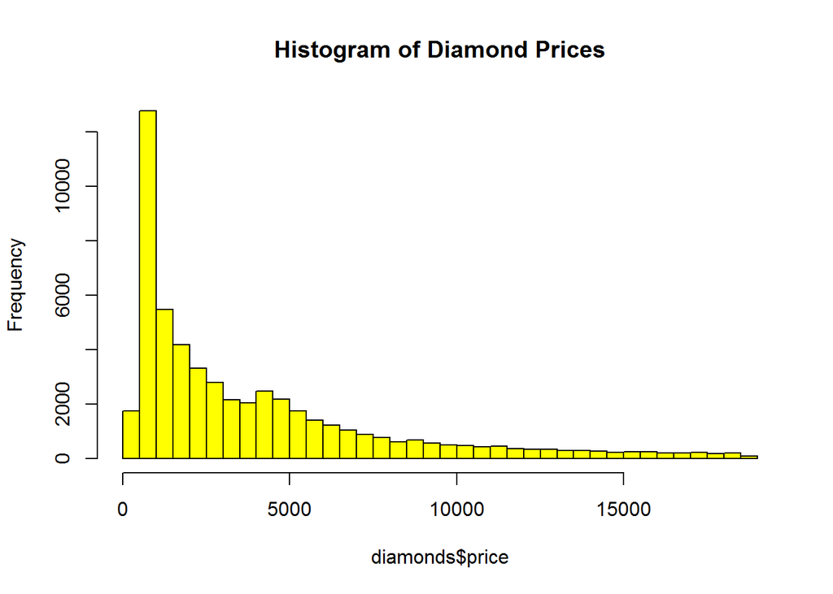

```r
hist(diamonds$price, main="Histogram of Diamond Prices", plot = T,breaks =40,col="yellow")
```

** How many diamonds cost less than $500?

```
Source: local data frame [1,729 x 10]

   carat       cut  color clarity depth table price     x     y     z
   (dbl)    (fctr) (fctr)  (fctr) (dbl) (dbl) (int) (dbl) (dbl) (dbl)
1   0.23     Ideal      E     SI2  61.5    55   326  3.95  3.98  2.43
2   0.21   Premium      E     SI1  59.8    61   326  3.89  3.84  2.31
3   0.23      Good      E     VS1  56.9    65   327  4.05  4.07  2.31
4   0.29   Premium      I     VS2  62.4    58   334  4.20  4.23  2.63
5   0.31      Good      J     SI2  63.3    58   335  4.34  4.35  2.75
6   0.24 Very Good      J    VVS2  62.8    57   336  3.94  3.96  2.48
7   0.24 Very Good      I    VVS1  62.3    57   336  3.95  3.98  2.47
8   0.26 Very Good      H     SI1  61.9    55   337  4.07  4.11  2.53
9   0.22      Fair      E     VS2  65.1    61   337  3.87  3.78  2.49
10  0.23 Very Good      H     VS1  59.4    61   338  4.00  4.05  2.39
..   ...       ...    ...     ...   ...   ...   ...   ...   ...   ...
```

** How many diamonds cost less than $250?**

```
Source: local data frame [0 x 10]

Variables not shown: carat (dbl), cut (fctr), color (fctr), clarity
  (fctr), depth (dbl), table (dbl), price (int), x (dbl), y (dbl), z (dbl)
```

**How many diamonds cost $15,000 or more?**

```
Source: local data frame [1,656 x 10]

   carat       cut  color clarity depth table price     x     y     z
   (dbl)    (fctr) (fctr)  (fctr) (dbl) (dbl) (int) (dbl) (dbl) (dbl)
1   1.60     Ideal      G     VS2  61.9    56 15000  7.53  7.47  4.64
2   1.54   Premium      E     VS2  62.3    58 15002  7.31  7.39  4.58
3   1.19     Ideal      F    VVS1  61.5    55 15005  6.82  6.84  4.20
4   2.10   Premium      I     SI1  61.5    57 15007  8.25  8.21  5.06
5   1.69     Ideal      D     SI1  60.8    57 15011  7.69  7.71  4.68
6   1.50 Very Good      G    VVS2  62.9    56 15013  7.22  7.32  4.57
7   1.73 Very Good      G     VS1  62.8    57 15014  7.57  7.72  4.80
8   2.02   Premium      G     SI2  63.0    59 15014  8.05  7.95  5.03
9   2.05 Very Good      F     SI2  61.9    56 15017  8.13  8.18  5.05
10  1.50 Very Good      F     VS1  61.6    58 15022  7.35  7.43  4.55
..   ...       ...    ...     ...   ...   ...   ...   ...   ...   ...
```

**Break Out the histogram of diamond prices by cut. You should have five histograms in separate panels on your resulting plot.**

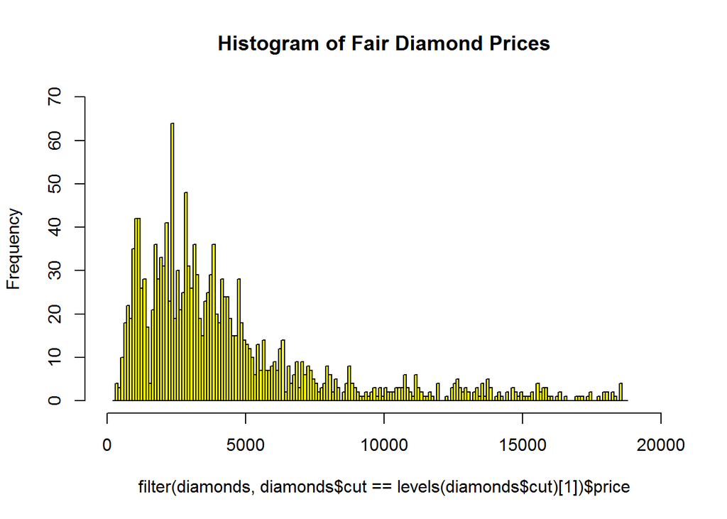

```r
hist(filter(diamonds,diamonds$cut == levels(diamonds$cut)[1])$price,
     main="Histogram of Fair Diamond Prices",
     plot = T,col="yellow",
     breaks=c(200, seq(300,18800, 100)),
     xlim=c(0, 20000),  ylim=c(0,70))
```

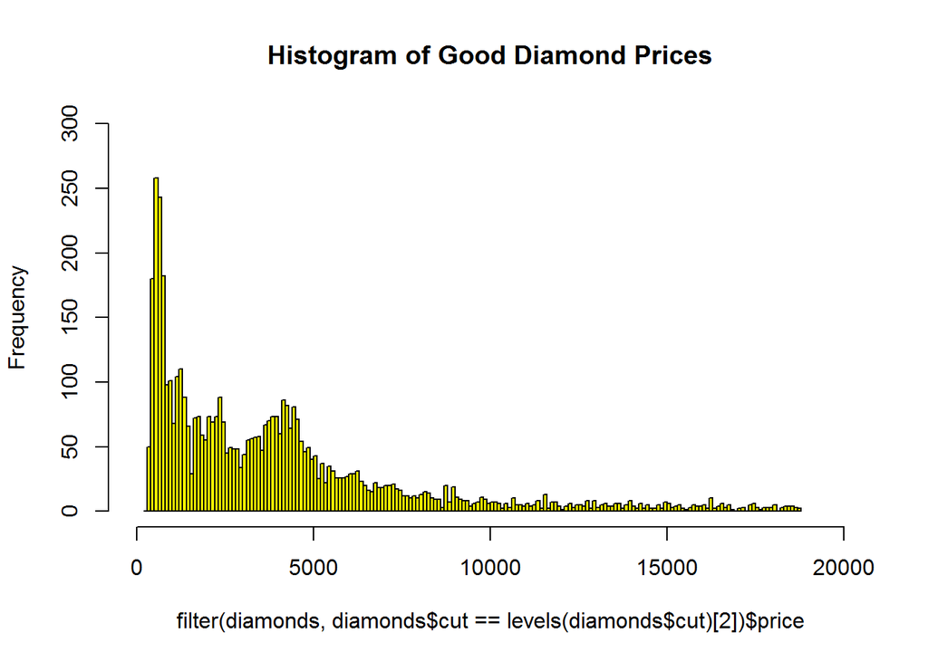

```r
hist(filter(diamonds,diamonds$cut == levels(diamonds$cut)[2])$price,
     main="Histogram of Good Diamond Prices",
     plot = T,col="yellow",
     breaks=c(200, seq(300,18800, 100)),
     xlim=c(0, 20000),  ylim=c(0,300))
```

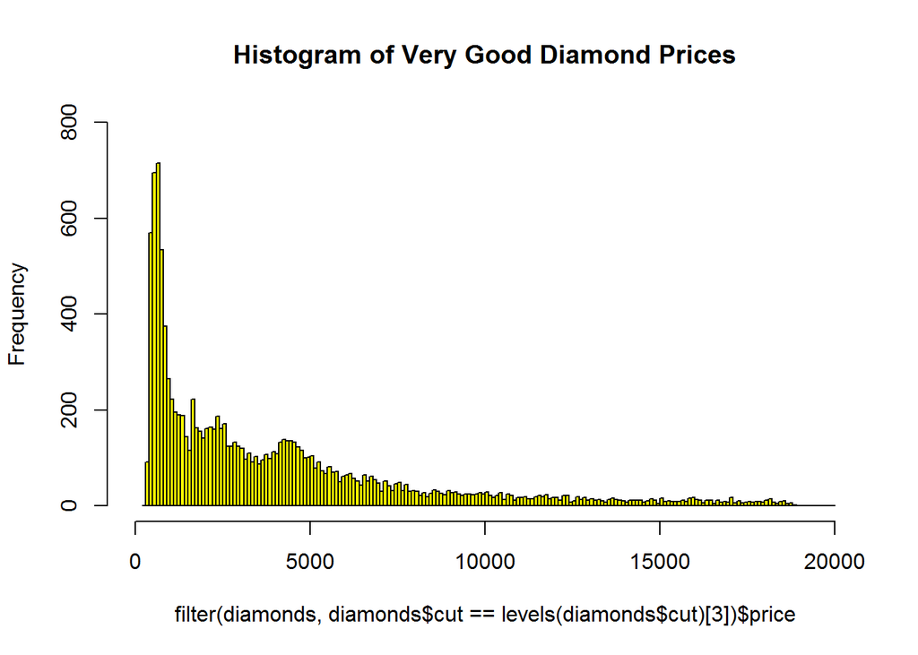

```r
hist(filter(diamonds,diamonds$cut == levels(diamonds$cut)[3])$price,
     main="Histogram of Very Good Diamond Prices",
     plot = T,col="yellow",
     breaks=c(200, seq(300,20000, 100)),
     xlim=c(0, 20000),  ylim=c(0,800))
```

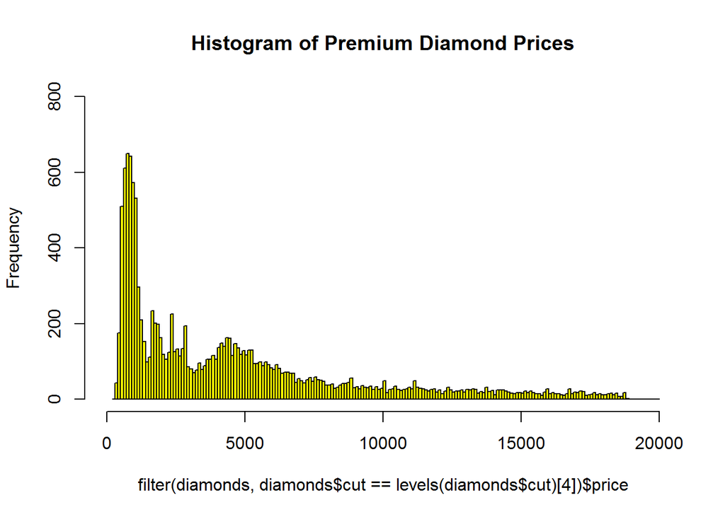

```r
hist(filter(diamonds,diamonds$cut == levels(diamonds$cut)[4])$price,
     main="Histogram of Premium Diamond Prices",
     plot = T,col="yellow",
     breaks=c(200, seq(300,20000, 100)),
     xlim=c(0, 20000),  ylim=c(0,800))
```

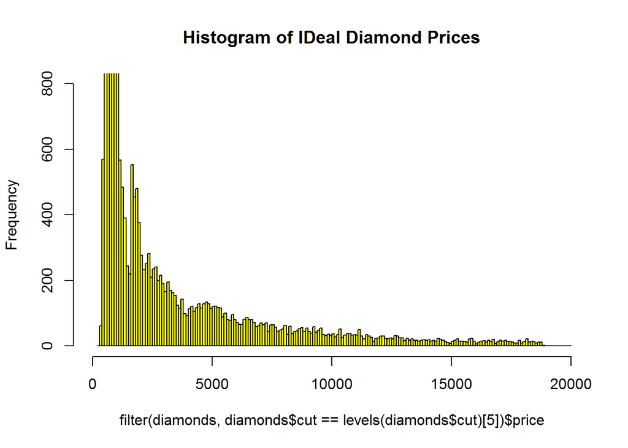

```r
hist(filter(diamonds,diamonds$cut == levels(diamonds$cut)[5])$price,
     main="Histogram of IDeal Diamond Prices",
     plot = T,col="yellow",
     breaks=c(200, seq(300,20000, 100)),
     xlim=c(0, 20000),  ylim=c(0,800))
```

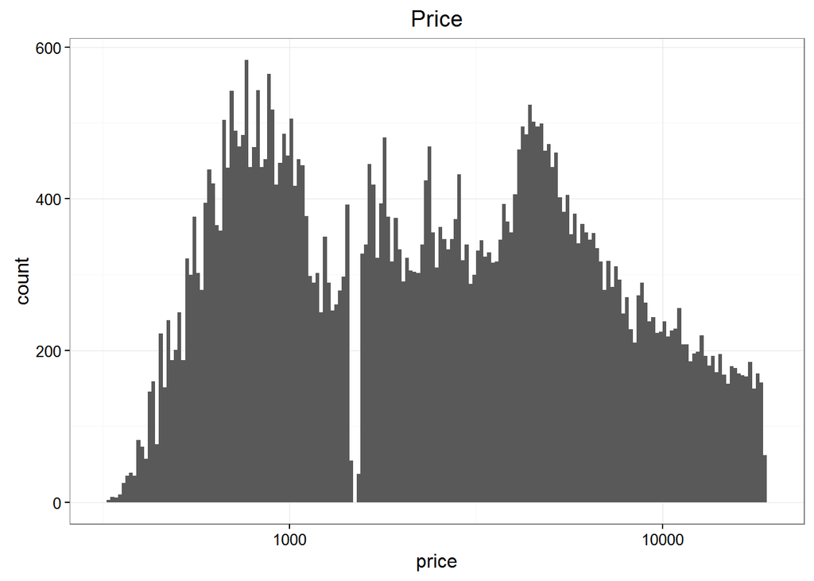

```r
 qplot(price, data = diamonds, binwidth = 0.01) + scale_x_log10() +
   theme_bw() +
   ggtitle("Price")
```

The command scales=“free_y” allows the y-axis to be different for each histogram. Also, see the difference between binwidth=10 vs binwidth=80

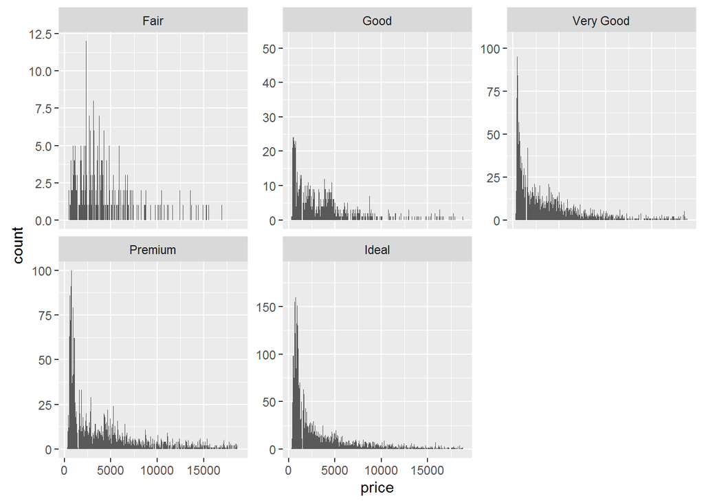

```r
qplot (x = price, data = diamonds, binwidth=10) + facet_wrap(~cut, scales="free_y")
```

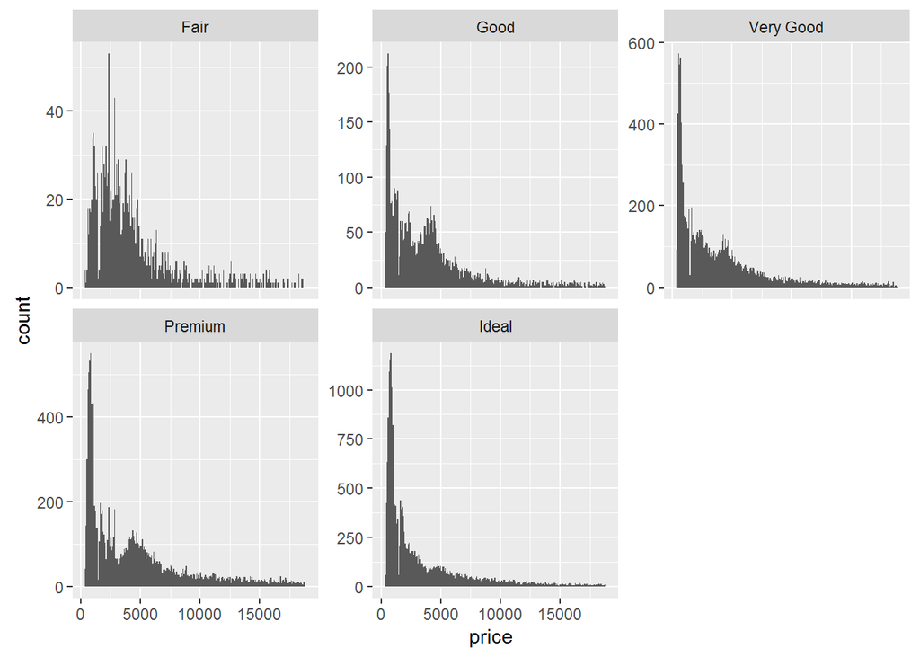

```r
qplot (x = price, data = diamonds, binwidth=80) + facet_wrap(~cut, scales="free_y")
```

The command scales=“free_y” allows the y-axis to be different for each histogram. Also, see the difference between binwidth=10 vs binwidth=80

```
Source: local data frame [5 x 5]

        cut mean_price median_price min_price max_price
     (fctr)      (dbl)        (dbl)     (int)     (int)
1      Fair   4358.758       3282.0       337     18574
2      Good   3928.864       3050.5       327     18788
3 Very Good   3981.760       2648.0       336     18818
4   Premium   4584.258       3185.0       326     18823
5     Ideal   3457.542       1810.0       326     18806
```

**Create a Histogram of price per carat and facet it by cut. You can make adjustmentsto the code from the previous exercise to get started. Adjust the bin width and transform the scale of the x-axis using log10**

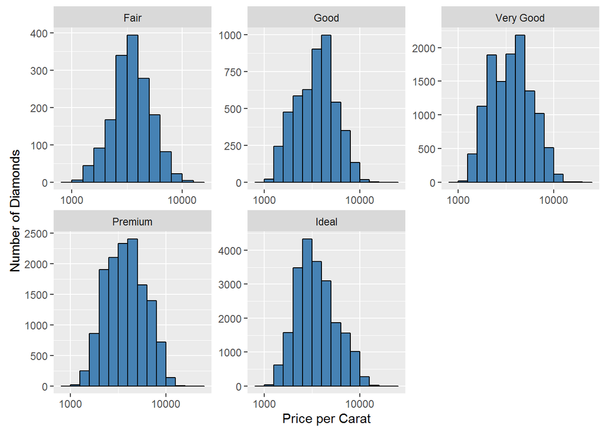

```r
ggplot(aes(x = (price / carat)), data = diamonds) +
geom_histogram(binwidth = 0.10,color = "black", fill = "steelblue") +
scale_x_log10() +
facet_wrap( ~ cut, scales = "free") +
labs(x = "Price per Carat", y = "Number of Diamonds")
```

Price vs. Carat - Vertical

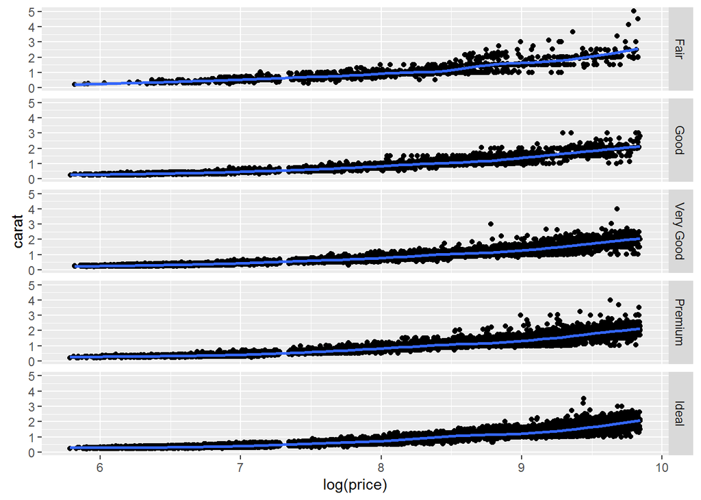

```r
qplot(log(price), carat, data = diamonds, facets = cut ~ .,
geom =c("point","smooth"))
```

Price vs. Carat - Horizontal

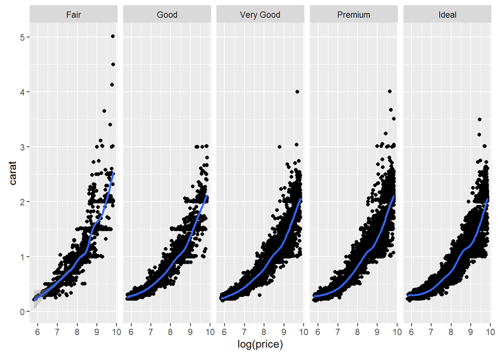

```r
qplot(log(price), carat, data = diamonds,
geom=c("point","smooth"),facets = . ~ cut)
```

Dividing Carat in quantiles

```
       0% 33.33333% 66.66667%      100%
     0.20      0.50      1.00      5.01
```

```
[1] "(0.2,0.5]" "(0.5,1]"   "(1,5.01]"
```

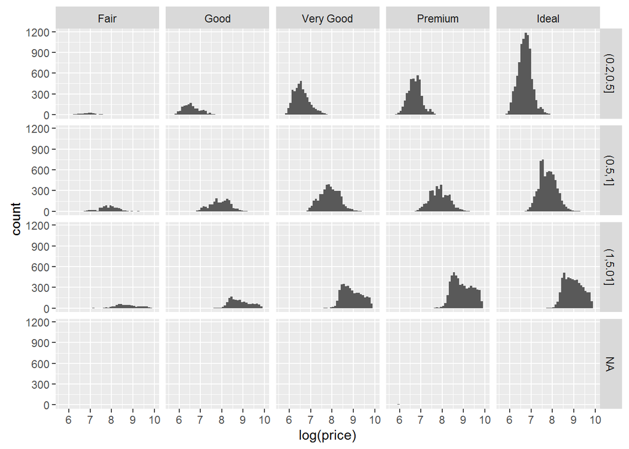

**Investigate the price of diamonds using box plots, numerical summaries, and one of the following categorical variables: cut, clarity, or color**

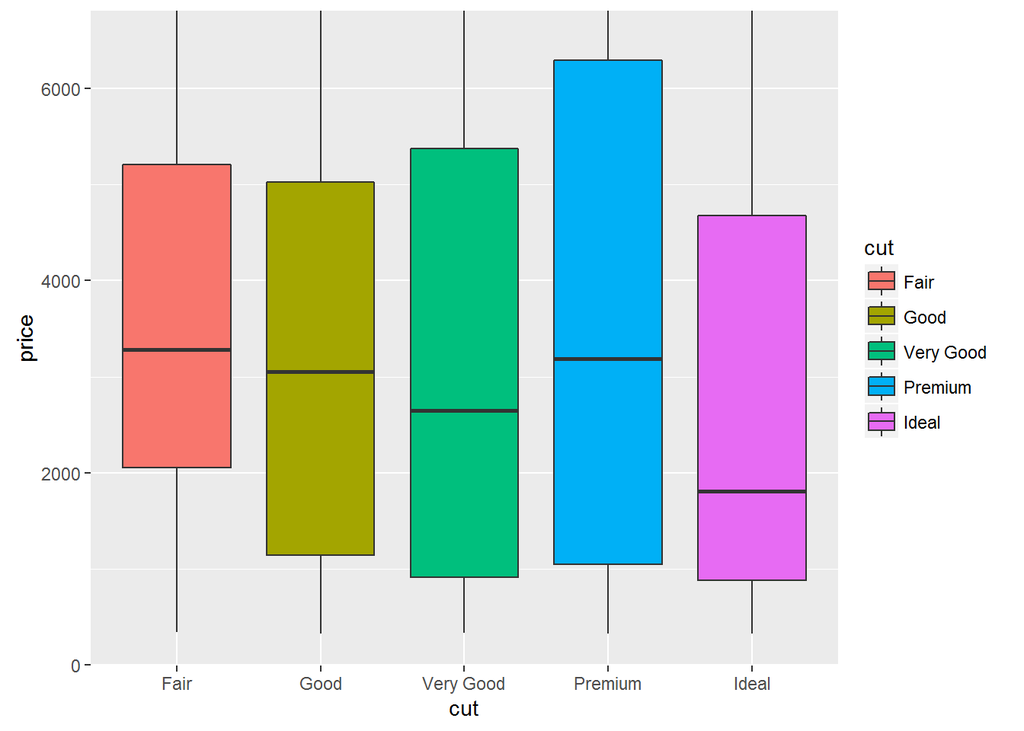

```
Source: local data frame [8 x 3]

  clarity maximum price minimun price
   (fctr)         (int)         (int)
1      I1         18531           345
2     SI2         18804           326
3     SI1         18818           326
4     VS2         18823           334
5     VS1         18795           327
6    VVS2         18768           336
7    VVS1         18777           336
8      IF         18806           369
```

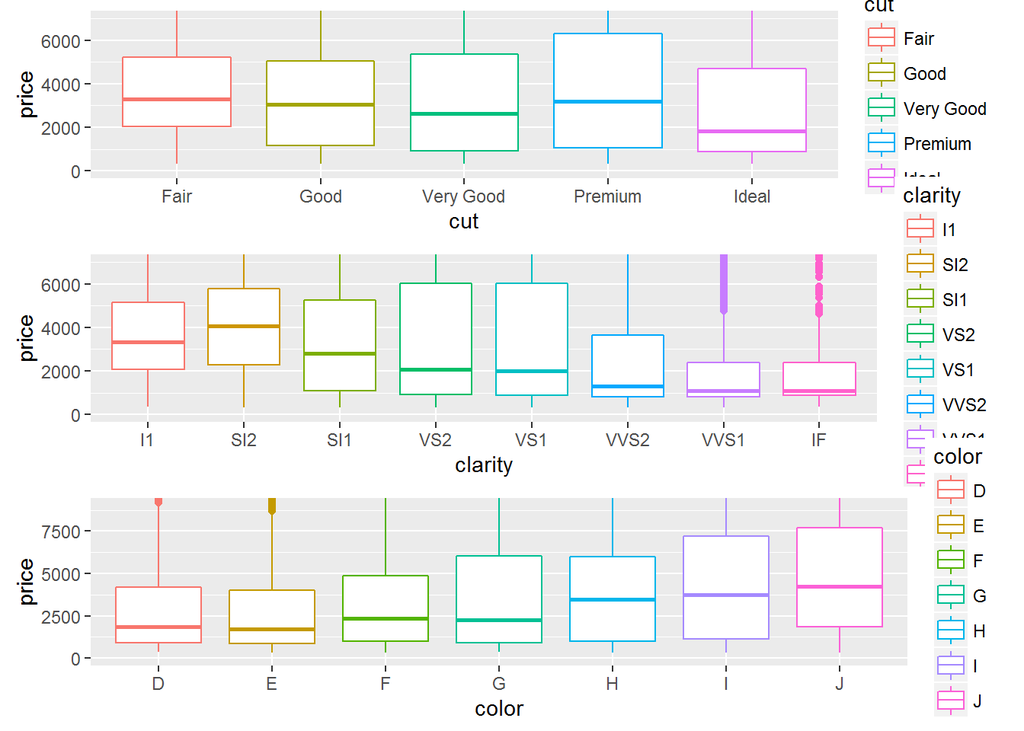

**What is the price range for the middle 50% of diamonds with color D?**  
First Quartile (25%): 911 Third Quartile (75%): 4214

```
 25%  50%  75%
 911 1838 4214
```

```
[1]   357.0   911.0  1838.0  4213.5 18693.0
```

```
 25%  50%  75%
 911 1838 4214
```

**What is the price range for the middle 50% of diamonds with color J?**  
First Quartile (25%): 1860 Third Quartile (75%): 7695

```
 25%  50%  75%
1859 4234 7695
```

```
[1]   335  1860  4234  7695 18710
```

```
 25%  50%  75%
1859 4234 7695
```

**What is the IQR for diamonds with the best color?**(D is the best color)  
3302

```
[1] 3302.5
```

**What is the IQR for diamonds with the worst color?**(D is the best color)  
5834

```
[1] 5834.5
```

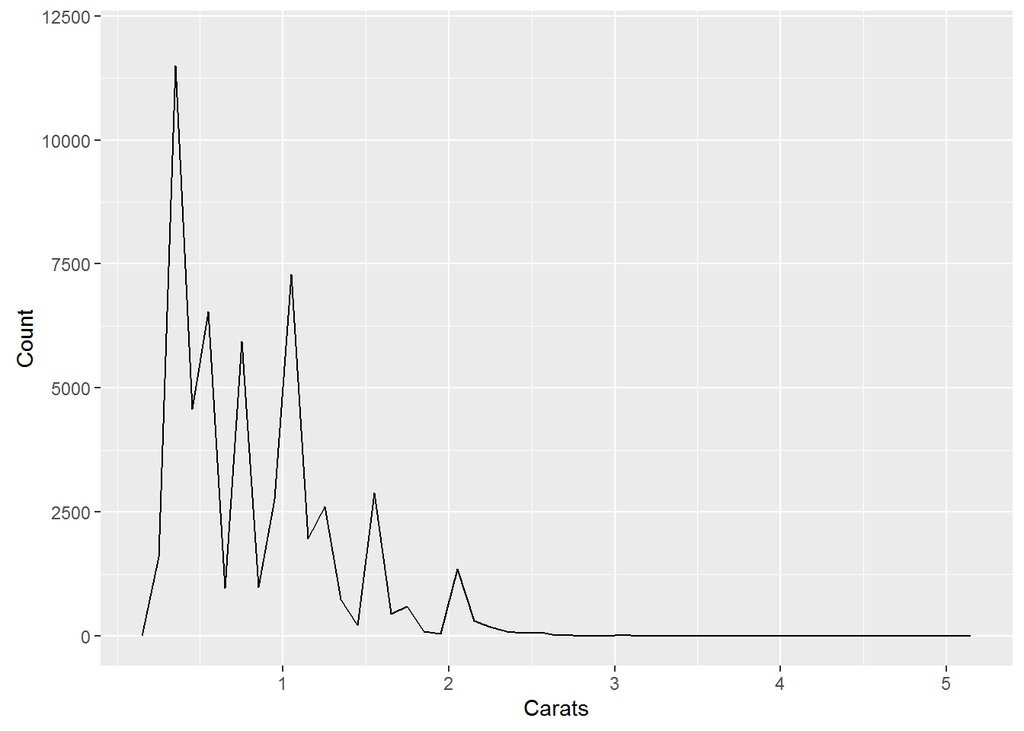

```r
qplot(x = diamonds$carat,
      data = diamonds,
      binwidth = 0.1,
      xlab = 'Carats',
      ylab = 'Count',
      geom = 'freqpoly') +
      scale_x_continuous(breaks=1:5) + scale_y_continuous(limits=c(0, 12000))
```

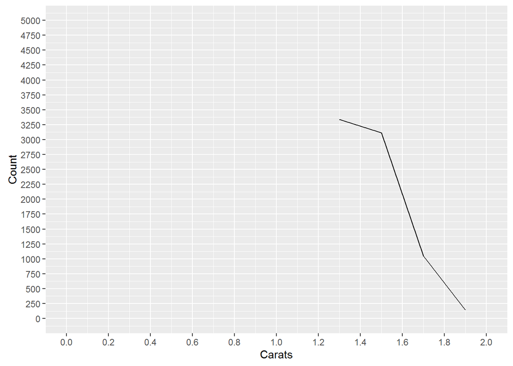

```r
qplot(x = diamonds$carat,
      data = diamonds,
      binwidth = 0.2,
      xlab = 'Carats',
      ylab = 'Count',
      geom = 'freqpoly') +
      scale_x_continuous(limits = c(0,2), breaks = seq(0,2,0.2) ) +
      scale_y_continuous(limits = c(0,5000), breaks = seq(0,5000,250))
```

**Zooming - Another look x-axis between 0 and 2**

```r
qplot(x = diamonds$carat,
      data = diamonds,
      binwidth = 0.1,
      xlab = 'Carats',
      ylab = 'Count',
      geom = 'freqpoly') +
      scale_x_continuous(limits = c(0,2), breaks = seq(0,2,0.1) ) +
      scale_y_continuous(limits = c(0,5000), breaks = seq(0,5000,250))
```

[output not shown]

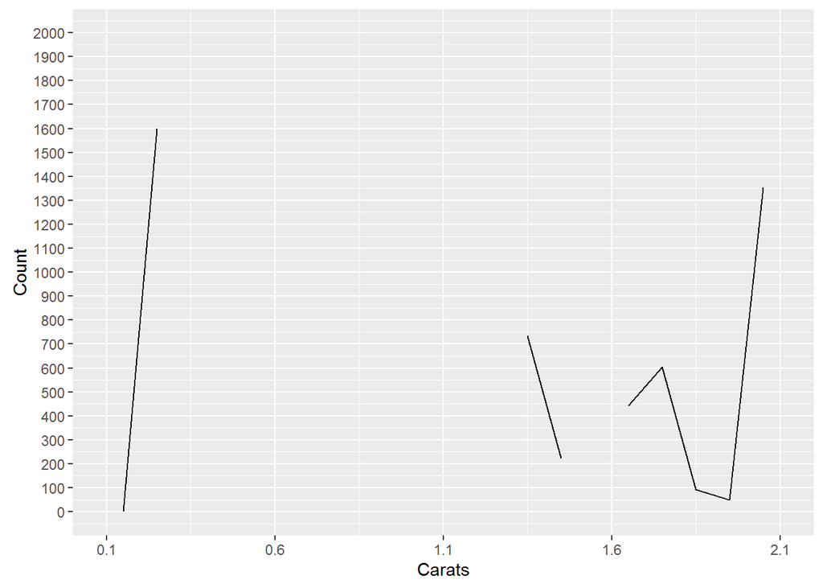

```r
qplot(x = diamonds$carat,
      data = diamonds,
      binwidth = 0.1,
      xlab = 'Carats',
      ylab = 'Count',
      geom = 'freqpoly') +
      scale_x_continuous(limits = c(0.1,2.1), breaks = seq(0.1,2.1,0.5) ) +
      scale_y_continuous(limits = c(0,2000), breaks = seq(0,2000,100))
```

**Another one** **Look how there is a binwidth and no breaks in the scale_x_continuous.** **In the next graphic (not the one below) you will see the a break in the scale_x_continuous**

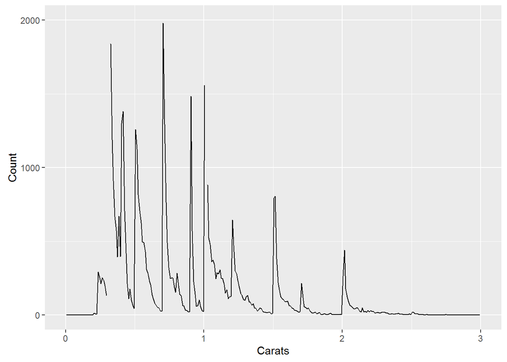

```r
qplot(x = diamonds$carat,
      data = diamonds,
      binwidth = 0.01,
      xlab = 'Carats',
      ylab = 'Count',
      geom = 'freqpoly') +
      scale_x_continuous(limits = c(0,3)) +
      scale_y_continuous(limits = c(0,2000), breaks = seq(0,2000,1000))
```

**Compare the following graphic with the previous one. Look how this time there is a tick for every 0.3. Also, we are omitting the break for the y axis**

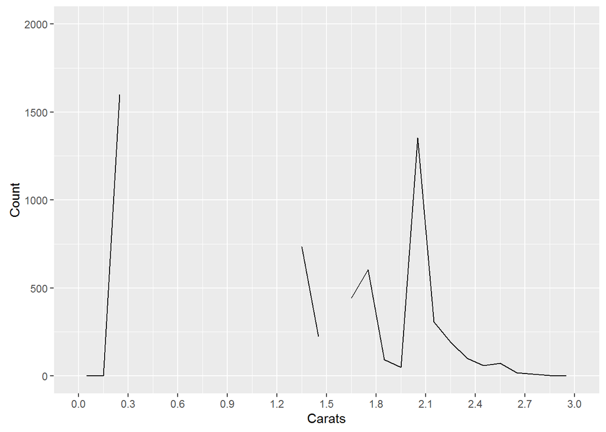

```r
qplot(x = diamonds$carat,
      data = diamonds,
      binwidth = 0.1,
      xlab = 'Carats',
      ylab = 'Count',
      geom = 'freqpoly') +
      scale_x_continuous(limits = c(0,3), breaks = seq(0,3, 0.3) )  +
      scale_y_continuous(limits = c(0,2000))
```